# STAT $1210$

Chapter $15$ Homework: Probability and Inference in Practice

Fall $2026$

### Question $1$

A university veterinary hospital recruits $80$ dogs receiving rehabilitation after knee surgery. The dogs are randomly assigned to either a new physiotherapy program or the hospital’s standard program, with $40$ dogs in each group. The dogs were not randomly sampled from all dogs undergoing knee surgery. After six weeks, the researchers compare mean mobility scores between the groups.

1. Identify the sample and a reasonable population of interest.
2. Was random sampling used? What does this imply about generalization?
3. Was random assignment used? What does this contribute to the study?
4. If the new-program group has a higher mean mobility score, can the study support a causal conclusion for the participating dogs? State one condition that remains important.
5. Explain why a valid causal conclusion for the participants does not automatically justify a conclusion about every dog undergoing knee surgery.

**Show solution**

1. The sample consists of the $80$ dogs treated at the university veterinary hospital and enrolled in the study. A possible population of interest is all dogs undergoing comparable knee surgery, although the sampling method may support conclusions only for dogs similar to those treated at this hospital.
2. Random sampling was not used. The researchers recruited dogs from one hospital, so the sample may differ systematically from dogs treated elsewhere (for example in breed mix, owner income, or the severity of cases referred to a university hospital). Generalization to all dogs undergoing knee surgery therefore requires caution.
3. Random assignment was used to determine the rehabilitation program. Random assignment tends to balance both known and unknown pre-treatment variables, such as age, weight and injury severity, between the groups. Any large difference in mobility after six weeks is then hard to attribute to anything other than the program, which strengthens a causal comparison.
4. Yes, the randomized design can support a causal conclusion for the participating dogs if the groups were treated similarly apart from the rehabilitation program. Important remaining conditions include adequate compliance with each program, reliable (ideally blinded) measurement of mobility and no treatment-related loss to follow-up.
5. Random assignment and random sampling serve different purposes. Random assignment supports a causal comparison within the study, whereas random sampling supports generalization to a population. The dogs came from one hospital rather than from a probability sample of all eligible dogs, so the causal effect observed may not be the same size in other populations of dogs.

### Question $2$

A marine research group studies the operating life of satellite tags attached to sea turtles. A random sample of $64$ tags from the current production process has mean operating life $\bar{x}=18.4$ months. For this exercise, treat the population standard deviation as known at $\sigma=4.8$ months.

1. Calculate the standard error of the sample mean.
2. Construct a $90\%$ confidence interval for the population mean operating life using $z^*=1.645$.
3. Construct a $95\%$ confidence interval using $z^*=1.960$.
4. Construct a $99\%$ confidence interval using $z^*=2.576$.
5. Compare the three intervals and explain why the interval width changes even though the sample data remain the same.

**Show solution**

1. The standard error is

   $$SE=\frac{\sigma}{\sqrt
   n}=\frac{4.8}{\sqrt{64}}=\frac{4.8}{8}=0.6\text{ months}$$

   This is the standard deviation of the sampling distribution of $\bar x$: sample means from samples of $64$ tags typically vary by about $0.6$ month around $\mu$.
2. The $90\%$ margin of error is

   $$m=1.645(0.6)=0.987$$

   Therefore, the interval is

   $$18.4\pm0.987=(17.413,\ 19.387)\text{ months}$$
3. The $95\%$ margin of error is

   $$m=1.960(0.6)=1.176$$

   Therefore, the interval is

   $$18.4\pm1.176=(17.224,\ 19.576)\text{ months}$$
4. The $99\%$ margin of error is

   $$m=2.576(0.6)=1.5456$$

   Therefore, the interval is

   $$18.4\pm1.5456=(16.8544,\ 19.9456)\text{ months}$$
5. All three intervals have centre $18.4$ months because they use the same sample mean. A higher confidence level requires capturing a larger central area of the Standard Normal curve, so the critical value $z^*$ is larger and the interval is wider. Greater long-run confidence is obtained at the cost of lower precision; the data themselves contain the same information in all three cases.

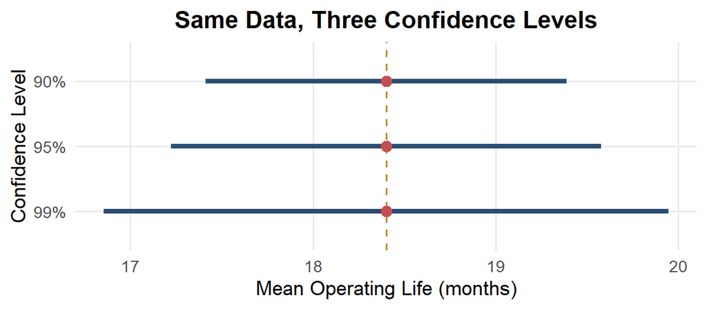

### Question $3$

A veterinary researcher wants to estimate the population mean recovery time after a routine procedure. Previous studies suggest that the population standard deviation is approximately $18$ minutes.

1. Find the smallest sample size required for a $95\%$ confidence interval with margin of error no greater than $4$ minutes.
2. Find the smallest sample size required if the desired margin of error is reduced to $2$ minutes.
3. Compare the answers to Parts $1$ and $2$. Explain the square-root relationship.
4. Find the smallest sample size required for a $99\%$ confidence interval with margin of error no greater than $4$ minutes. Use $z^*=2.576$.
5. Use the R code in the solution to verify the three sample sizes. Why must every result be rounded up?

**Show solution**

1. Start from $m=z^*\sigma/\sqrt n$ and solve for $n$:

   $$n=\left(\frac{z^*\sigma}{m}\right)^2$$

   At $95\%$ confidence with $m=4$,

   $$n=\left(\frac{1.960(18)}{4}\right)^2=(8.82)^2=77.7924$$

   Therefore, the researcher needs at least

   $$\boxed{n=78}$$
2. For $m=2$,

   $$n=\left(\frac{1.960(18)}{2}\right)^2=(17.64)^2=311.1696$$

   Therefore,

   $$\boxed{n=312}$$
3. Cutting the margin of error from $4$ minutes to $2$ minutes requires four times as many observations ($311.17 = 4 \times 77.79$ before rounding). Because $m$ is proportional to $1/\sqrt n$, dividing $m$ by $2$ requires multiplying $\sqrt n$ by $2$, which means multiplying $n$ by $2^2=4$.
4. At $99\%$ confidence,

   $$n=\left(\frac{2.576(18)}{4}\right)^2=(11.592)^2=134.3745$$

   Therefore,

   $$\boxed{n=135}$$

   The higher confidence level uses a larger critical value, so a larger sample is needed to keep the margin of error at $4$ minutes.
5. The calculations are verified below. Each value is rounded up because rounding down would produce a margin of error larger than the stated target. For example, with $n=77$ the $95\%$ margin is $1.960(18)/\sqrt{77}\approx4.02$ minutes, which exceeds $4$.

```r
sigma <- 18

n_95_margin_4 <- ceiling((qnorm(0.975) * sigma / 4)^2)
n_95_margin_2 <- ceiling((qnorm(0.975) * sigma / 2)^2)
n_99_margin_4 <- ceiling((qnorm(0.995) * sigma / 4)^2)

c(
  n_95_margin_4 = n_95_margin_4,
  n_95_margin_2 = n_95_margin_2,
  n_99_margin_4 = n_99_margin_4
)
```

```
## n_95_margin_4 n_95_margin_2 n_99_margin_4
##            78           312           135
```

### Question $4$

A municipal public-health office randomly selects $5000$ residents and invites them to complete an online survey. Only $9\%$ of those selected respond. The survey asks, “Do you support the responsible plan to improve community health services?” Among respondents, $62\%$ answer yes. A report presents the result as $62\%\pm4.5\%$.

1. What source of uncertainty does the reported margin of error attempt to measure?
2. Identify two important problems that the margin of error does not measure.
3. Explain why selecting the original $5000$ residents randomly does not remove the concern created by the low response rate.
4. Could the reported interval be narrow but still miss the true population proportion by more than $4.5$ percentage points? Explain.
5. Describe two changes that would improve the credibility of the study.

**Show solution**

1. The margin of error attempts to measure random sample-to-sample variation under the assumed sampling model. It describes how much the sample proportion could vary because different residents might have been selected. (With $0.09 \times 5000 = 450$ respondents, a $95\%$ margin for a proportion near $0.62$ is about $1.96\sqrt{0.62(0.38)/450}\approx0.045$, which is where the $\pm4.5\%$ comes from.)
2. The margin does not measure nonresponse bias: respondents may have different opinions from the $91\%$ who did not respond. It also does not measure response bias caused by the favourable wording “responsible plan.” Other concerns include inaccurate responses and undercoverage of residents with limited internet access.
3. Random selection identifies a probability sample at the invitation stage, but most selected residents did not respond. The final respondent group may no longer resemble the selected sample or the population if the decision to respond is related to opinions about the plan, for example if supporters of the plan were more motivated to reply. Randomization only protects the sample that actually provides data.
4. Yes. A narrow interval describes precision under the assumed model. Systematic bias shifts the entire interval away from the true population value, and the ordinary sampling margin does not quantify that bias. A precise estimate of the wrong quantity is still wrong.
5. The office could use neutral wording (for example, “Do you support or oppose the proposed plan…”) and follow up with selected nonrespondents through several contact methods. It should also report the response rate, compare respondents with the sampling frame when possible and describe any weighting or adjustment used for nonresponse.

### Question $5$

A wildlife rehabilitation centre states that $75\%$ of rehabilitated seals survive for at least $30$ days after release. Researchers independently track $40$ comparable released seals, and $23$ survive for at least $30$ days. Let $X$ be the number that survive.

1. State suitable null and alternative hypotheses for investigating whether the survival probability is below $0.75$.
2. State the null distribution of $X$ and list the main binomial conditions.
3. Write the exact conditional probability that gives the P-value, and calculate it.
4. At $\alpha=0.05$, what conclusion should the researchers draw? Interpret the P-value in context.
5. Use `pbinom()` in R to verify the probability.

**Show solution**

1. The hypotheses are

   $$H_0:p=0.75$$

   $$H_a:p<0.75$$

   where $p$ is the probability that a comparable rehabilitated seal survives at least $30$ days after release.
2. Under the null hypothesis,

   $$X\sim\operatorname{Bin}(40,0.75)
   \qquad
   E(X)=40(0.75)=30$$

   The study has a fixed number of $40$ trials, each seal is classified as surviving or not surviving, the probability is treated as common across comparable seals and the outcomes must be sufficiently independent (for example, seals should not be released together in a way that makes their survival linked).
3. Under $H_0$ we would expect about $30$ survivors; we observed $23$, which is in the direction of $H_a$. Because $H_a$ is lower-tailed, counts of $23$ or fewer are at least as extreme as the observed result. The P-value is

   $$\begin{aligned}
   P(X\leq23\mid H_0)
   &=P(X\leq23\mid p=0.75)\\
   &=\sum_{x=0}^{23}\binom{40}{x}(0.75)^x(0.25)^{40-x}\\
   &\approx0.0116
   \end{aligned}$$
4. Because $0.0116<0.05$, the result is statistically significant at the $5\%$ level. The researchers reject $H_0$ and conclude that the data provide evidence that the population survival probability is below $0.75$. If the true probability were $0.75$, observing $23$ or fewer survivors among $40$ releases would occur in only about $1.16\%$ of comparable studies. The P-value is not the probability that the centre’s claim is true.
5. The R calculation is below. The argument `q = 23` includes every count from $0$ through $23$, matching the summation.

```r
pbinom(q = 23, size = 40, prob = 0.75)
```

```
## [1] 0.01156136
```

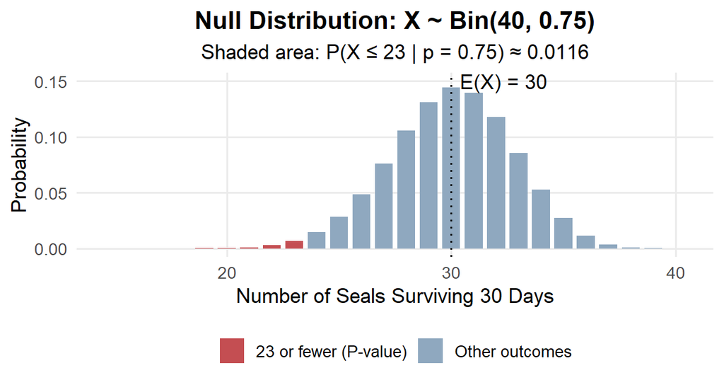

### Question $6$

A wildlife-monitoring program historically records an average of $10$ bird collisions per month near a group of wind turbines. During one month, investigators record $18$ collisions. Let $X$ denote the monthly collision count.

1. State suitable hypotheses for investigating whether the monthly event rate has increased.
2. Under the historical-rate model, state the probability distribution of $X$.
3. Use the complement rule to write and calculate the exact upper-tail P-value.
4. State the conclusion at $\alpha=0.05$ and identify two practical assumptions that should be investigated before attributing the result to a higher underlying collision rate.
5. Use `ppois()` in R to verify the probability. Explain why the R calculation uses $17$ rather than $18$ as its value of `q`.

**Show solution**

1. The hypotheses are

   $$H_0:\lambda=10$$

   $$H_a:\lambda>10$$

   where $\lambda$ is the mean number of collisions per month.
2. Under $H_0$,

   $$X\sim\operatorname{Pois}(10)
   \qquad
   E(X)=10$$
3. The upper-tail alternative makes counts of $18$ or more at least as extreme as the observation. That tail has infinitely many terms, so the complement rule is used:

   $$\begin{aligned}
   P(X\geq18\mid H_0)
   &=1-P(X\leq17\mid\lambda=10)\\
   &=1-\sum_{x=0}^{17}e^{-10}\frac{10^x}{x!}\\
   &\approx0.0143
   \end{aligned}$$
4. Because $0.0143<0.05$, the observed count provides evidence against the stable historical rate of $10$ collisions per month. Under the historical rate, $18$ or more collisions would happen in only about $1.4\%$ of months. Before attributing the result to a higher underlying rate, investigators should assess whether monitoring effort and exposure remained comparable (more searching finds more carcasses). They should also consider seasonality, migration, changes in turbine operation and clustering of events during one incident, such as a storm, which violates the Poisson independence assumption.
5. With `lower.tail = FALSE`, R calculates $P(X>q)$. Setting `q = 17` therefore gives $P(X>17)=P(X\geq18)$ for an integer-valued count. Using `q = 18` would calculate $P(X\geq19)$ and leave out the observed value.

```r
ppois(q = 17, lambda = 10, lower.tail = FALSE)
```

```
## [1] 0.01427761
```

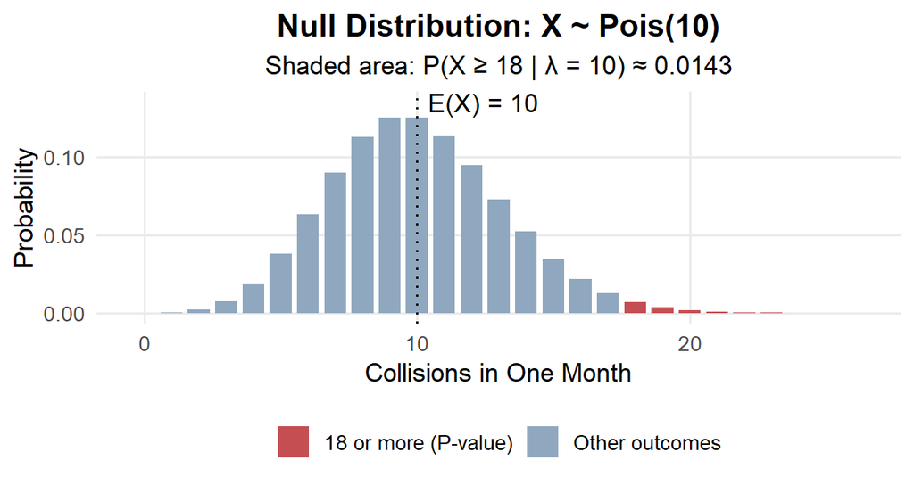

### Question $7$

A laboratory compares the population mean level of a blood biomarker with a reference value $\mu_0$. In two independent studies, the observed sample mean is $0.30$ unit above the reference value. Treat the population standard deviation as known at $\sigma=2.4$ units. Study A has $n=25$, whereas Study B has $n=400$.

1. State the hypotheses for a two-sided test.
2. Calculate the standard error, test statistic and P-value for Study A.
3. Calculate the standard error, test statistic and P-value for Study B.
4. Compare the statistical conclusions at $\alpha=0.05$. Why do the conclusions differ when the estimated effect is the same?
5. Does Study B show that a difference of $0.30$ unit is biologically important? What additional information is needed?

**Show solution**

1. The hypotheses are

   $$H_0:\mu=\mu_0$$

   $$H_a:\mu\ne\mu_0$$
2. For Study A,

   $$SE_A=\frac{2.4}{\sqrt{25}}=0.48$$

   $$z_A=\frac{\bar x-\mu_0}{SE_A}=\frac{0.30}{0.48}=0.625$$

   The two-sided P-value adds both tails:

   $$2P(Z\geq0.625)\approx0.5320$$
3. For Study B,

   $$SE_B=\frac{2.4}{\sqrt{400}}=0.12$$

   $$z_B=\frac{0.30}{0.12}=2.50$$

   The two-sided P-value is

   $$2P(Z\geq2.50)=2(1-0.9938)\approx0.0124$$
4. Study A fails to reject $H_0$ ($0.532>0.05$), whereas Study B rejects $H_0$ ($0.0124<0.05$). The test statistic measures the effect in standard-error units. The larger sample in Study B produces a standard error four times smaller ($\sqrt{400/25}=4$), so the same $0.30$-unit effect is $2.5$ standard errors from $\mu_0$ in Study B but only $0.625$ standard errors in Study A. Study A’s non-significant result does not show that $\mu=\mu_0$; the study simply had too little precision to detect a difference this size.
5. No. The P-value measures compatibility with the null model, not biological importance. Researchers need the effect estimate, a confidence interval, measurement units, natural biological variation and a scientifically meaningful threshold. Costs, risks and consequences may also matter.

The two P-values can be verified in R.

```r
effect <- 0.30
sigma <- 2.4

z_A <- effect / (sigma / sqrt(25))
z_B <- effect / (sigma / sqrt(400))

p_A <- 2 * pnorm(-abs(z_A))
p_B <- 2 * pnorm(-abs(z_B))

c(z_A = z_A, p_A = p_A, z_B = z_B, p_B = p_B)
```

```
##        z_A        p_A        z_B        p_B
## 0.62500000 0.53197106 2.50000000 0.01241933
```

### Question $8$

A wildlife genetics study tests $20$ independent genetic markers. Each test uses significance level $\alpha=0.05$. Assume that every null hypothesis is true.

1. What is the probability that one particular test does not produce a false positive?
2. Calculate the probability that none of the $20$ tests produces a false positive.
3. Calculate the probability of at least one false positive among the $20$ tests.
4. What is the expected number of false positives? Explain why selective reporting of only significant results would be misleading.
5. A simple Bonferroni approach uses $\alpha/20$ for each test. What per-test significance level would be used, and what trade-off does this introduce?

**Show solution**

1. For one test with a true null hypothesis, a false positive has probability $\alpha$, so by the complement rule

   $$P(\text{no false positive})=1-0.05=0.95$$
2. Under the stated independence assumption, the multiplication rule gives

   $$P(\text{no false positives in }20\text{
   tests})=(0.95)^{20}\approx0.3585$$
3. Using the complement rule,

   $$\begin{aligned}
   P(\text{at least one false positive})
   &=1-(0.95)^{20}\\
   &\approx0.6415
   \end{aligned}$$

   Equivalently, the number of false positives $Y$ follows $\operatorname{Bin}(20,0.05)$, and this is $P(Y\geq1)=1-P(Y=0)$.
4. The expected number is

   $$E(Y)=np=20(0.05)=1$$

   Even when no marker has a real association, the study should expect about one “significant” marker. Reporting only the significant markers hides the number of tests that were performed and makes chance findings appear more convincing than they are.
5. The Bonferroni per-test level is

   $$\frac{0.05}{20}=0.0025$$

   With this level, $P(\text{at least one false positive})=1-(1-0.0025)^{20}\approx0.049$, back below $0.05$ for the whole family. The trade-off is that each test now requires much stronger evidence, which reduces power and increases the chance of false negatives (Type II errors) for markers that do have real effects.

### Question $9$

A veterinary trial studies the mean reduction in a pain score produced by a new treatment. Let positive values represent improvement. The planned one-sided test is

$$H_0:\mu=0
\qquad
H_a:\mu>0$$

The population standard deviation is treated as known at $\sigma=1.2$ points. The test uses $\alpha=0.05$ and $n=20$. A mean reduction of $0.7$ point is considered scientifically meaningful.

1. Find the critical sample mean above which the test rejects $H_0$.
2. Assuming that the true mean reduction is $0.7$ point, standardize the critical sample mean under this alternative distribution.
3. Calculate the power of the test against $\mu=0.7$.
4. Calculate $\beta$ at $\mu=0.7$ and describe the Type I and Type II errors in context.
5. Use R to verify the power for $n=20$ and calculate the power if the sample size increases to $n=30$. Explain the change.

**Show solution**

1. The standard error under the null model is

   $$SE=\frac{1.2}{\sqrt{20}}\approx0.2683$$

   For an upper-tail test with $\alpha=0.05$, the critical value is $z^*=1.645$ (the value with area $0.05$ to its right). The critical sample mean is

   $$\bar{x}_{\mathrm{crit}}=\mu_0+z^*\,SE=0+1.645(0.2683)\approx0.4414$$

   The decision rule is: reject $H_0$ when $\bar{x}\geq0.4414$.
2. When the true mean is $0.7$, $\bar X$ is centred at $0.7$ with the same standard error, so

   $$z=\frac{0.4414-0.7}{0.2683}\approx-0.964$$
3. The power is the probability of landing in the rejection region when $\mu=0.7$:

   $$\begin{aligned}
   \text{Power}
   &=P(\bar X\geq0.4414\mid\mu=0.7)\\
   &=P(Z\geq-0.964)\\
   &\approx0.832
   \end{aligned}$$

   (With the table and $z=-0.96$: $1-0.1685=0.8315$. Software gives $0.8324$.)
4. The Type II error probability at $\mu=0.7$ is the probability of falling in the fail-to-reject region:

   $$\beta=P(\bar X<0.4414\mid\mu=0.7)=1-0.832=0.168$$

   A Type I error means concluding that the treatment produces a positive population mean reduction when the true mean reduction is $0$; its probability is $\alpha=0.05$, computed under the $\mu=0$ curve. A Type II error at $\mu=0.7$ means failing to detect improvement when the true population mean reduction is $0.7$ point; its probability $\beta\approx0.168$ is computed under the $\mu=0.7$ curve. For example, if the trial observed $\bar x=0.40$, it would fail to reject $H_0$; if the true mean were $0.7$, that conclusion would be a Type II error.
5. Increasing the sample size from $20$ to $30$ increases the power from approximately $0.832$ to $0.939$. With $n=30$, $SE=1.2/\sqrt{30}\approx0.2191$ and the cutoff moves down to $1.645(0.2191)\approx0.3604$. The larger sample makes both sampling distributions narrower, so they overlap less and a real reduction of $0.7$ is detected more often.

```r
alpha <- 0.05
sigma <- 1.2
meaningful_mean <- 0.7

calculate_power <- function(n) {
  standard_error <- sigma / sqrt(n)
  critical_mean <- qnorm(1 - alpha) * standard_error

  pnorm(
    critical_mean,
    mean = meaningful_mean,
    sd = standard_error,
    lower.tail = FALSE
  )
}

c(power_n20 = calculate_power(20), power_n30 = calculate_power(30))
```

```
## power_n20 power_n30
## 0.8324500 0.9394526
```

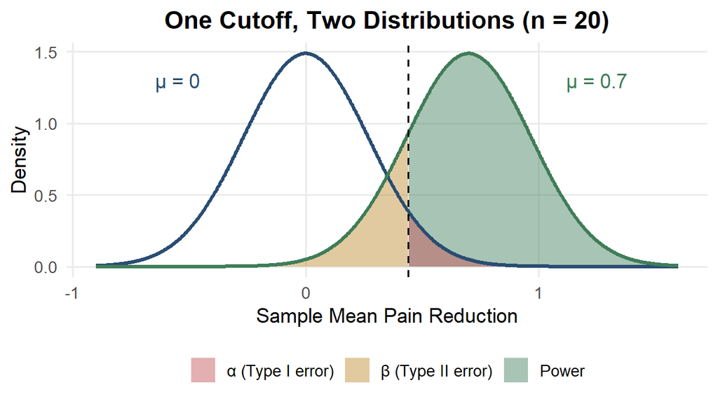

### Question $10$

Researchers study a nutritional supplement for dairy cows. They recruit $800$ cows from four conveniently selected farms and randomly assign the cows within each farm to the supplement or a control diet. The researchers examine $18$ outcomes but report only the significant results. For milk production, they report an estimated mean increase of $0.12$ litre per cow per day, a $95\%$ confidence interval of $(0.04,0.20)$ litre and $P=0.003$. During the study, $22\%$ of cows in the supplement group and $4\%$ of cows in the control group leave the study.

1. What aspect of the design supports a causal comparison? What feature limits generalization?
2. Explain how the unequal loss of cows from the two groups threatens the causal interpretation even though the original assignment was random.
3. Interpret the confidence interval and P-value correctly. What does neither quantity establish?
4. If all $18$ null hypotheses were true and the tests were independent at $\alpha=0.05$, calculate the probability of at least one false positive.
5. Evaluate whether the reported evidence is sufficient to recommend the supplement. Identify at least three additional pieces of information or analysis that should be reported.

**Show solution**

1. Random assignment within each farm supports a causal comparison of the diets for the cows who remain appropriately represented in the analysis. The four farms were conveniently selected, so the study may not generalize to farms with different breeds, management systems, climates or feeding practices.
2. Differential attrition can destroy the comparability created by random assignment. If cows leave the supplement group because of adverse effects, poor response or other outcome-related reasons, the remaining supplement group may consist mainly of cows that tolerated or responded well to it. The remaining supplement group may then no longer be comparable with the remaining control group, and the estimated benefit could be biased upward.
3. We are $95\%$ confident that, for cows like those in the study, the supplement increases mean milk production by between $0.04$ and $0.20$ litre per cow per day; “$95\%$ confident” means the method captures the true mean difference in about $95\%$ of repeated studies under the model assumptions. The P-value means that, if the supplement had no effect, a difference at least as large as the one observed would occur with probability $0.003$. Neither quantity establishes broad generalizability, absence of bias (such as that from attrition) or practical importance.
4. The family-level probability is

   $$\begin{aligned}
   P(\text{at least one false positive})
   &=1-(1-0.05)^{18}\\
   &=1-(0.95)^{18}\\
   &\approx0.6028
   \end{aligned}$$

   The expected number of false positives is $18(0.05)=0.9$. Note also that a Bonferroni threshold for $18$ tests would be $0.05/18\approx0.0028$, so the reported $P=0.003$ would no longer be significant after this adjustment.
5. The reported evidence is not sufficient by itself. The mean increase is small and must be compared with a meaningful production threshold, costs and animal-health consequences. The report should include all $18$ tested outcomes, the pre-specified analysis plan, an adjustment or discussion for multiple testing, reasons for attrition, an analysis that preserves the original randomization when appropriate, adverse events and confidence intervals for the main effects. Independent replication on a broader set of farms would strengthen the evidence.

### Question $11$

A provincial fish hatchery raises Atlantic salmon smolts for release. Historically, the mean weight of smolts at release has been $45$ g. This season, a random sample of $n=64$ smolts has mean weight $\bar{x}=46.8$ g. Treat the population standard deviation as known at $\sigma=6$ g, and assume the observations are independent.

1. Define the parameter $\mu$ in this context and calculate the standard error of $\bar{x}$.
2. Construct a $95\%$ confidence interval for the population mean smolt weight using $z^*=1.960$.
3. Interpret the interval in context.
4. At the $\alpha=0.05$ significance level, test whether the population mean weight this season differs from $45$ g. State the hypotheses, calculate the test statistic and the two-sided P-value using the Standard Normal table, and state your conclusion in context.
5. Explain how the confidence interval from Part $2$ leads to the same decision as the test in Part $4$.
6. Construct a $99\%$ confidence interval using $z^*=2.576$. Would the test reject $H_0$ at $\alpha=0.01$? Explain using both the interval and the P-value.

**Show solution**

1. $\mu$ is the population mean weight, in grams, of all smolts raised at the hatchery this season. The standard error is

   $$SE=\frac{\sigma}{\sqrt n}=\frac{6}{\sqrt{64}}=\frac{6}{8}=0.75\text{
   g}$$
2. The $95\%$ margin of error is

   $$m=1.960(0.75)=1.47$$

   so the interval is

   $$46.8\pm1.47=(45.33,\ 48.27)\text{ g}$$
3. We are $95\%$ confident that the population mean weight of this season’s smolts is between $45.33$ g and $48.27$ g. “$95\%$ confident” refers to the method: intervals built this way capture the true mean in about $95\%$ of repeated random samples. It does not mean there is a $95\%$ probability that $\mu$ lies in this particular interval.
4. The hypotheses are

   $$H_0:\mu=45
   \qquad
   H_a:\mu\neq45$$

   The test statistic is

   $$z=\frac{\bar x-\mu_0}{\sigma/\sqrt n}=\frac{46.8-45}{0.75}=2.40$$

   From the table, $P(Z\leq2.40)=0.9918$, so $P(Z\geq2.40)=1-0.9918=0.0082$. Because the alternative is two-sided, both tails count:

   $$P\text{-value}=2(0.0082)=0.0164$$

   Since $0.0164<0.05$, we reject $H_0$. There is evidence that this season’s mean smolt weight differs from the historical $45$ g; the sample suggests that smolts are heavier this season.
5. A two-sided test at level $\alpha$ rejects $H_0:\mu=\mu_0$ exactly when $\mu_0$ falls outside the $(1-\alpha)$ confidence interval. The $95\%$ interval $(45.33,\ 48.27)$ does not contain $45$, so $45$ is not a plausible value of $\mu$ at the $95\%$ level, which matches rejecting $H_0$ at $\alpha=0.05$. Both procedures use the same quantities: $45$ lies outside the interval because $|\bar x-45|=1.8$ is larger than the margin $1.96(0.75)=1.47$, which is the same as $|z|=2.40>1.96$.
6. The $99\%$ margin is $2.576(0.75)=1.932$, so the interval is

   $$46.8\pm1.932=(44.868,\ 48.732)\text{ g}$$

   This interval contains $45$, so the test would **not** reject $H_0$ at $\alpha=0.01$. The P-value agrees: $0.0164>0.01$. The evidence is strong enough for a $5\%$ standard but not for the stricter $1\%$ standard.

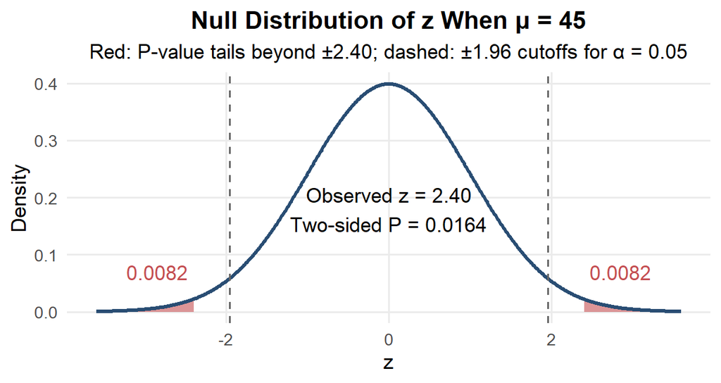